# bikesharing

## Plot 4

Comparing mean of rides within each day of week by member type

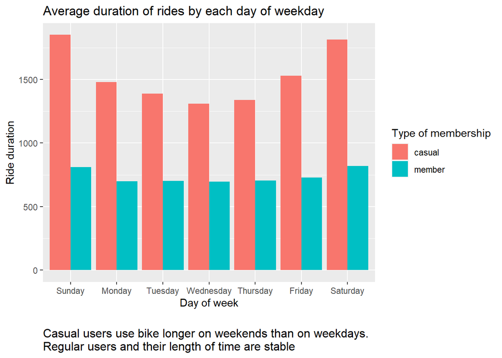

```r
rides_and_mean_by_day_and_member %>%
  ggplot(aes(x = weekday, y = average_duration, fill = member_casual)) +
  geom_col(position = "dodge") +
  labs(title = "Average duration of rides by each day of weekday",
       y = "Ride duration",
       x = "Day of week",
       caption = "Casual users use bike longer on weekends than on weekdays.\nRegular users and their length of time are stable",
       fill="Type of membership") +
  theme(plot.caption = element_text(margin=margin(t=20), size=12,hjust=0))
```

## Plot 5

Comparing number of rides within each month by member type

[figure not shown]

```r
all_trips_v2 %>%
  group_by(member_casual, month) %>%
  summarise(number_of_rides = n()
  ,average_duration = mean(ride_length)) %>%
  arrange(member_casual, month) %>%
  ggplot(aes(x = month, y = number_of_rides, fill = member_casual)) +
  geom_col(position = "dodge") +
    labs(title = "Number of rides by each month",
       y = "Number of rides",
       x = "Month",
       caption = "In both cases, it can be seen that the number of trips increases as the temperature increases",
       fill="Type of membership") +
  theme(plot.caption = element_text(margin=margin(t=20), size=12,hjust=0))
```

## Plot 6

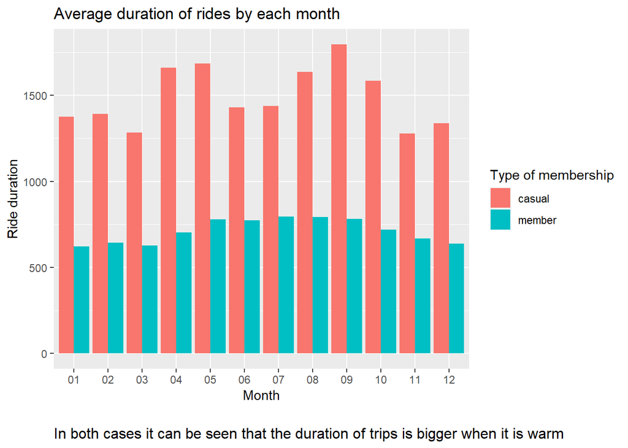

```r
all_trips_v2 %>%
  group_by(member_casual, month) %>%
  summarise(number_of_rides = n()
  ,average_duration = mean(ride_length)) %>%
  arrange(member_casual, month) %>%
  ggplot(aes(x = month, y = average_duration, fill = member_casual)) +
  geom_col(position = "dodge") +
    labs(title = "Average duration of rides by each month",
       y = "Ride duration",
       x = "Month",
       caption = "In both cases it can be seen that the duration of trips is bigger when it is warm",
       fill="Type of membership") +
  theme(plot.caption = element_text(margin=margin(t=20), size=12,hjust=0))
```

## Questions and answers

#### Why would casual riders buy Cyclistic annual memberships ?

- To save on rides because they use them longer than the users who have annual memberships
- It may also be about convenience of use
- They may be encouraged by advertising campaigns

#### How can Cyclistic use digital media to influence casual riders to become members?

- The idea is to pay attention to the length of the rides and the high cost associated with it - on weekends, casual users use bike-sharing longer and more frequent. It is worth to pay attention to possibility of saving when they buy annual membership. They could take advantage by longer trips and less cost associated with this longer trips. The point is to make them more flexible on weekends and charge them less costs.
- It can be seen thar regular customers use it most often during the week. It is possible they use this solution to get to work. Maybe some of casual users also commute by bike-sharing. The idea is to encourage casual users to start commuting by bike-sharing or use it more frequent. This could led to change of thinking of casual riders to buy annual membership.
- Finally, recommendation that is based on increasing investment outlay before warm months and keep promoting during these months